# Prediction Assignment

# Predicting Weight-Lifting Exercise Quality

*Practical Machine Learning course project*

## Executive summary

Accelerometer records from six participants were used to predict the five-level `classe` outcome. Identifiers, timestamps, window metadata, and variables with at least 5% missing values were excluded, leaving 52 sensor predictors. Five-fold stratified cross-validation compared random forest and extremely randomized trees; a separate 25% stratified holdout provided an additional check. Extra trees produced mean cross-validation accuracy of **99.54%** (estimated out-of-sample error **0.46%**) and holdout accuracy of **99.69%**. Random forest reached 99.31% and 99.55%, respectively. Both final models produced the same predictions for all 20 test cases.

## Data processing

The row index, participant identity, timestamps, and window metadata were removed before splitting. Columns with at least 5% missing values were excluded, leaving 52 numeric sensor predictors.

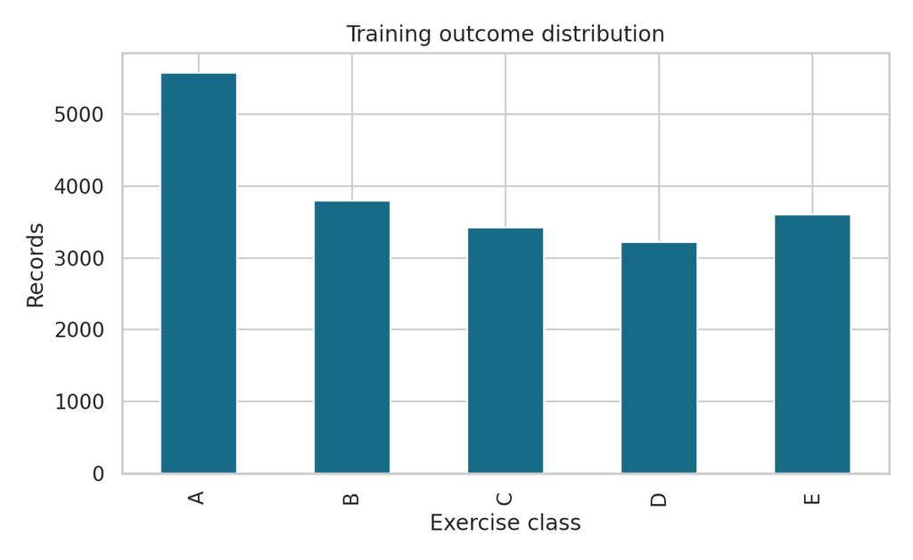

Training outcome distribution

## Validation and model choice

The validation workflow used five-fold stratified cross-validation and a 25% stratified holdout. Extra trees had the lower cross-validation error and was selected. The confusion matrices show few errors and no class was systematically collapsed into another.

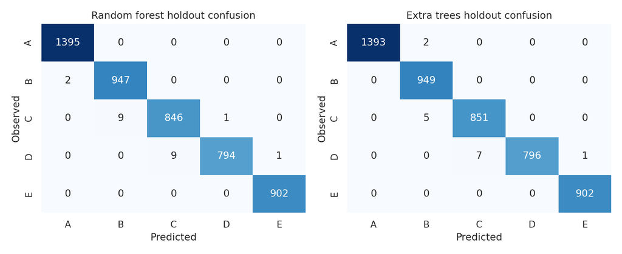

Holdout confusion matrices

The strongest predictors are measurements from the belt, dumbbell, arm, and forearm; no identifier or timestamp is used.

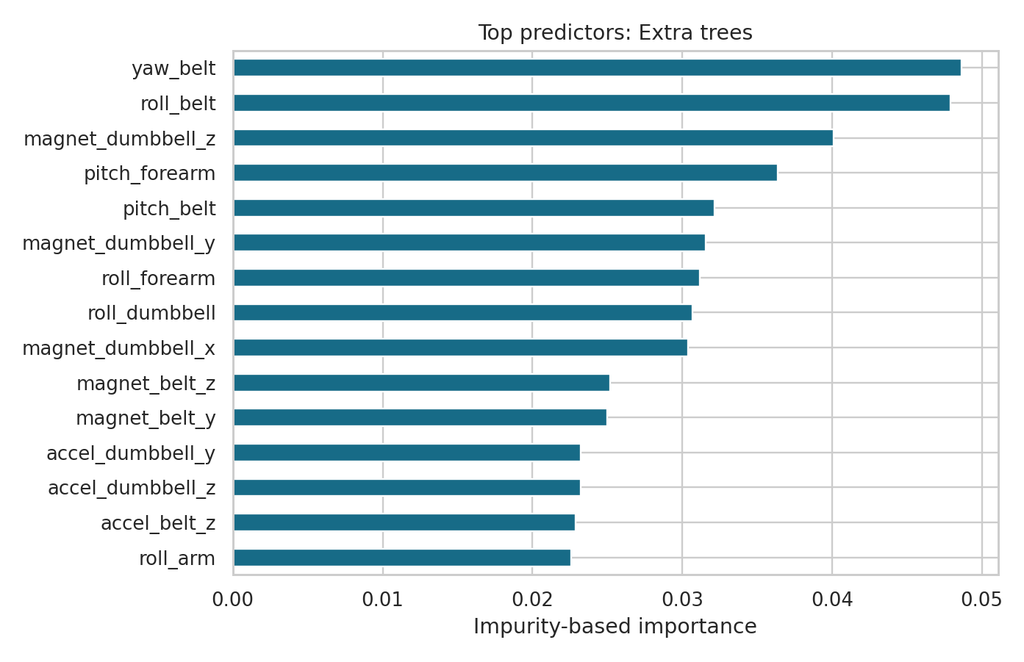

Top predictor importance

## Expected out-of-sample error

Mean five-fold accuracy for extra trees was 0.99545, so the estimated error for new records from a similar participant and task distribution is 0.00455. This does not estimate performance for entirely unseen people, because folds contain records from the same six participants. Holdout accuracy of 0.99694 is consistent with cross-validation.

## Test predictions

The 20 predictions in `problem_id` order are:

`B, A, B, A, A, E, D, B, A, A, B, C, B, A, E, E, A, B, B, B`.

See `Prediction_Assignment.Rmd` for the complete reproducible R workflow.